# Mass spectrometry and advances in clinical laboratories Cameron Shedlock and Dr. Katherine Stumpo **Data parsing in Mass Spectrometry Imaging using R Studio: A tutorial**

Cameron Shedlock (cameron.shedlock@scranton.edu)

Dr. Kate Stumpo (katherine.stumpo@bruker.com)

## Tutorial Objective

Mass spectrometry imaging (MSI) has emerged as a rapidly expanding field in the MS community. The analysis of large spectral data is further complicated by spatial information in MSI. A plethora of resources exist for expert users to begin parsing MSI data in R, but there is a critical lack of guidance for absolute beginners. This tutorial is designed to serve as a one stop guide to start using R with MSI data.

## Why use R for MSI

A host of powerful R packages have been created to enable efficient and relevant analysis of MSI data in R. This tutorial will guide users through a simple step by step workflow to allow MSI data to be analyzed in R without requiring a background in R or MSI. R packages have been optimized to load complex MSI data with a few simple commands. R has a host of packages for MSI which include powerful analytical methods accessible to beginners.

## Start using R

Depending on your familiarity with R, the following resources are designed to guide beginners through the user interface to start using this notebook.

https://education.rstudio.com/learn/beginner/ https://rstudio-education.github.io/hopr/starting.html

With R and R Studio installed, the user interface can be quickly understood through freely available videos and guides such as the resources provided by RStudio itself.

## Prepare packages and data

```r
# install packages
if (!requireNamespace("BiocManager", quietly = TRUE))
    install.packages("BiocManager")
BiocManager::install("Cardinal")
```

```r
# load MSI package Cardinal
library(Cardinal)
```

With the Cardinal package installed and an imaging dataset downloaded, we are ready to begin.

## MSI Data Processing

The defining feature of MSI is the spatial component of the data. In order to make m/z images, data first needs to be read into R and processed.

```r
# use your terminal or OS to find the file path of the .imzml file of your MSI data
data_path_example <- "the/path/to/your/.imzml/imaging/data"
data_path <- "D:\\Data Storage\\Converted IMZML Datasets\\KS_Zebrafish_2AuNP_5AuNP_DHB_20\\KS_Zebrafish_2AuNP_5AuNP_DHB_20.imzML"
```

```r
# use Cardinal function to easily load the complicated MSI data structure into R with only 2 lines of code
data <- readMSIData(data_path)
```

Now the object **data** is your MSI dataset loaded into R for further analysis. Many packages and data parsing methods can be used through R to make discoveries from the data.

## Data Preprocessing

Raw data can be analyzed but preprocessing is the standard for MSI experiments. This step reduces the computational resources and time required for analysis and can be tuned for specific needs. The parameters such as total ion count (tic) and root mean square (rms) are listed in Cardinal documentation and user changable. The most important parameter is the signal to noise ratio (SNR). This number dictates how much more intense a peak must be than the noise region to be considered a real peak. By increasing this number a smaller number of more intense peaks will be used for analysis. If a particular peak is desired, it is useful to make an m/z image and display its spectrum before and after preprocessing to verify this step retains the target.

```r
# preprocess datasets
data_proc <- data %>% # %>% this is a pipe operator. It performs the following steps on "data" and saves the resulting object as "data_proc"

  #normalize the spectra
  normalize(method="tic") %>%
  #select main peaks, those below SNR will be zero
  peakPick(method="mad", SNR=5) %>%
  #align spectra to given peaks or mean spectra if left empty
  peakAlign(tolerance=0.5, units="mz") %>%
  #remove low frequency peaks
  peakFilter(freq.min=0.01, rm.zero=TRUE) %>%
  #process
  process()
```

```
## nrows changed from 26700 to 1630
```

### Target Confirmation

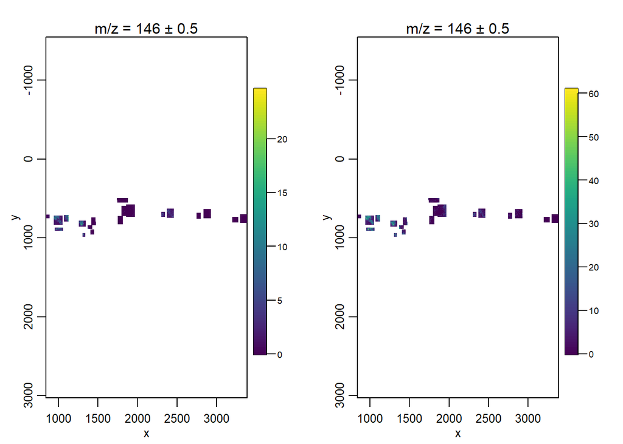

```r
target <- 146
# verify target remains after preprocessing
# create image of target before preprocessing
before <- image(data, mz=target, plusminus=0.5)
# create image of target after preprocessing
after <- image(data_proc, mz=target, plusminus=0.5)
# display before
print(before, layout=c(1,2))
# display after
print(after, layout=FALSE)
```

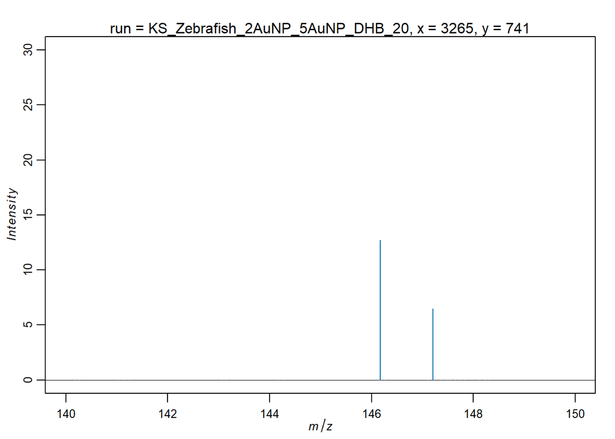

```r
# plotting the spectrum from a random (here number 5) pixel of the processed data. Adjust x and y to contain an appropriate intensity for y and the m/z value in the x range
plot(data_proc, pixel=11000, xlim=c(140,150), ylim=c(0,30))
```

```r
# note the pixel is chosen to have a corresponding (x,y) coordinate on the sample. This is derived from the image.
```

## Making m/z images

The defining feature of MSI is the m/z image. By simply changing the value of the **mz** in the code, a new image with a new target can be created.

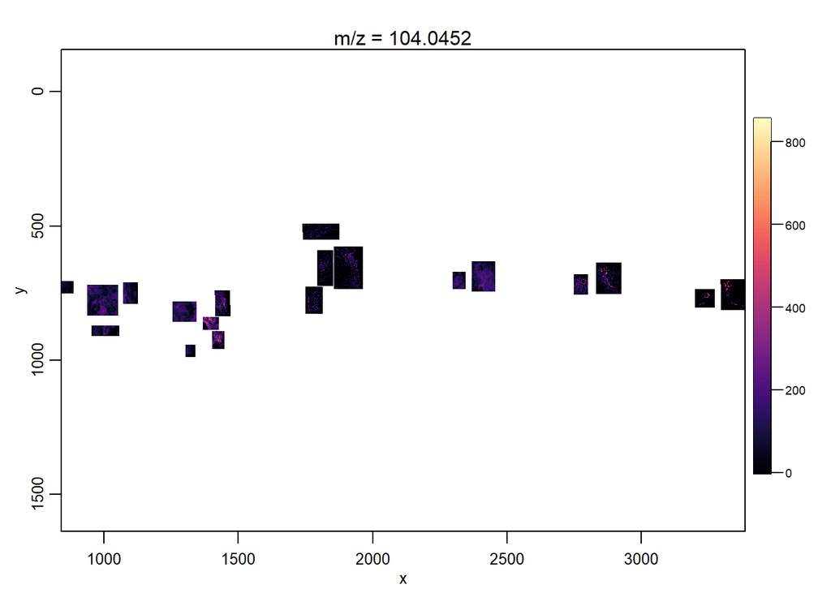

```r
image(data_proc, mz=104, colorscale=magma)
```

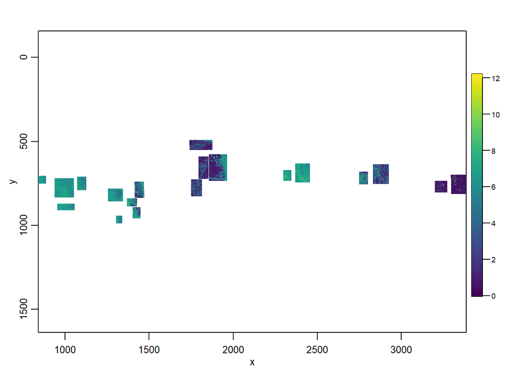

```r
# intensity for all pixels in run
image(data_proc)
```

This image is signal for the entire processed dataset. By changing the parameters in the code specific m/z values can be used along with changing the color theme. Cardinal offers dark and light themes along with cividis, magma, inferno, and plasma for colorscales. An m/z image of the whole dataset is useful for quickly visualizing signal hotspots and trends without further analysis. Furthermore, the image generated can be used to estimate coordinates for particular areas of the slide.

## Selecting a desired ROI

This code enables the user to chose coordinates from the previous m/z image of the entire imaging run. By using estimated coordinates a select region can be turned into an R object. This is useful for targeted analysis of specific sections and having a smaller object for later processing.

```r
# cut an imaging run into a smaller object
# save features of data
features <- features(data_proc)
# select desired pixel range to form square arount region of interest
pixels <- pixels(data_proc,
                x>= 2250 & x<=3500,
                y>= 625 & y<=850)
# make object with features of selected area
data_cut <- data_proc[features,pixels]
```

Now when the smaller chunk is projected as an image it only includes the desired region.

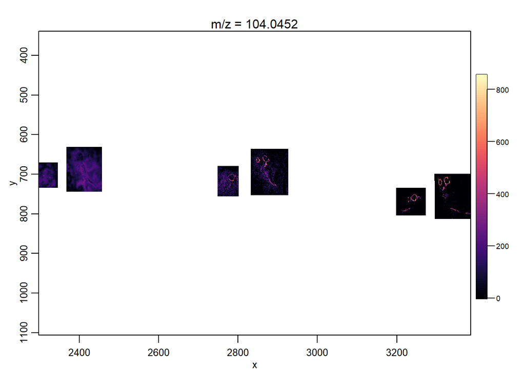

```r
# image of selected area
image(data_cut,
      mz=104,
      colorscale=magma)
```

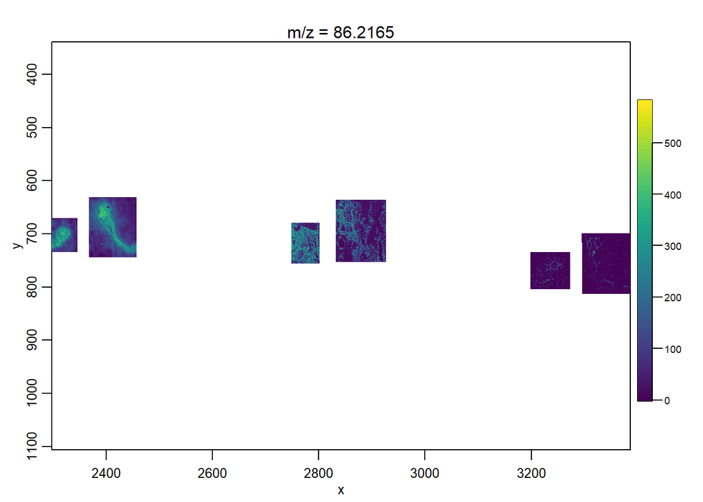

```r
# image any m/z value
# simply change the mz= aparameter to target
image(data_cut, mz=86.21196)
```

## Unsupervised data exploration

Data dimension reducing techniques such as principal component analysis and spatial shrunken centroids can be used to parse MSI datasets without the need for targeted user inputs.

```r
# ssc
data_proc_ssc <- spatialShrunkenCentroids(data_proc, method="adaptive", r=2, s=15, k=4)
# save created object
saveRDS(data_proc_ssc, file="data_proc_ssc_new.rds")
```

In the spatial shrunken centroid function there are four user changable parameters, which are method, r, s, and k. K is the number of segments and what is most often changed by the user. R is the shrinkage parameter and s alters the way peaks are chosen.

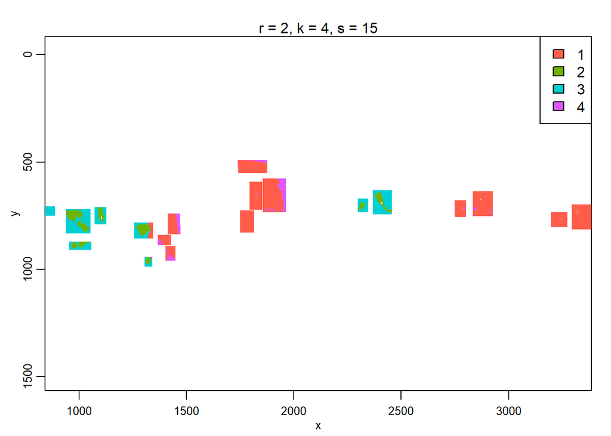

```r
# image results of ssc
ssc <- image(data_proc_ssc,
             model=list(s=15))
ssc
```

### Analysis of SSC

```r
# determine top m/z features
topFeatures(data_proc_ssc, model=list(s=15), class == 2)
```

```
## Top-ranked features:
##           mz count       freq r k  s class   centers statistic
## 1  184.28504 43745 0.34335118 2 4 15     2 256.14417  646.9344
## 2  147.21064 49406 0.38778393 2 4 15     2 114.14313  614.1169
## 3   86.27770 44807 0.35168673 2 4 15     2 318.15212  611.2457
## 4   72.27624 25251 0.19819318 2 4 15     2  72.62282  454.9673
## 5   87.30807 37284 0.29263928 2 4 15     2  56.68679  439.2428
## 6  185.31779 25215 0.19791062 2 4 15     2  29.83917  391.6039
## 7  146.26699 46318 0.36354646 2 4 15     2  41.13210  373.6848
## 8  166.29970 20051 0.15737877 2 4 15     2  21.61741  369.6334
## 9   71.26435 21731 0.17056497 2 4 15     2  24.55040  346.7850
## 10 206.33796  9703 0.07615811 2 4 15     2  24.92451  311.0347
```

## Principal Component Analysis

Dimension reduction by orthogonal transformation is accomplished in PCA which has emerged as a common approach for unsupervised exploration of MSI data.

```r
# PCA
# ncomp parameter is number of principal components
data_proc_pca <- PCA(data_proc, ncomp=4)
# save object due to longer run time
saveRDS(data_proc_pca, file="data_proc_pca_new.rds")
```

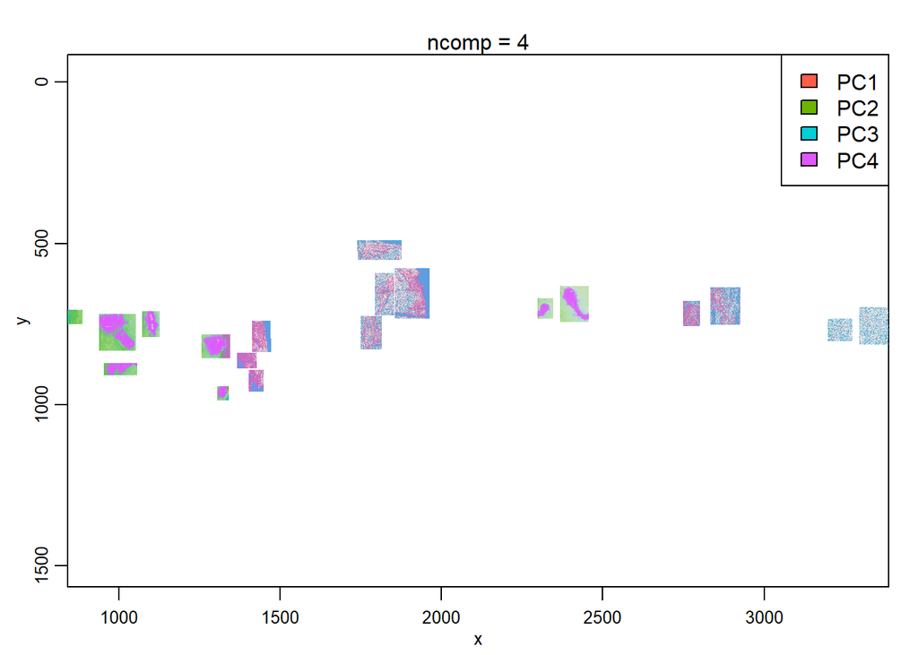

```r
# image results of PCA
image(data_proc_pca, contrast.enhance="histogram", normalize.image="linear")
```